# Exponential Random Graph Models (ERGMs) using statnet

Statnet Development Team

*Last updated 2022-07-05*

*This tutorial is a joint product of the Statnet Development Team:*

Pavel N. Krivitsky (University of New South Wales)  
Martina Morris (University of Washington)  
Mark S. Handcock (University of California, Los Angeles)  
Carter T. Butts (University of California, Irvine)  
David R. Hunter (Penn State University)  
Steven M. Goodreau (University of Washington)  
Chad Klumb (University of Washington)  
Skye Bender de-Moll (Oakland, CA)  
Sam Jenness (Emory University) Michal Bojanowski (Kozminski University)

The network modeling software demonstrated in this tutorial is authored by Pavel Krivitsky (`ergm`) and Carter Butts (`network` and `sna`).

## The `statnet` Project

All `statnet` packages are open-source, written for the **R** computing environment, and published on CRAN. The source repositories are hosted on [GitHub](https://github.com/statnet). Our website is [statnet.org](http://statnet.org/)

- Need help? For general questions and comments, please email the statnet users group at statnet_help@uw.edu. You’ll need to join the listserv if you’re not already a member. You can do that here: [statnet_help listserve](https://mailman13.u.washington.edu/mailman/listinfo/statnet_help).
- Found a bug in our software? Please let us know by filing an issue in the appropriate package [GitHub repository](https://github.com/statnet), with a reproducible example.
- Want to request new functionality? We welcome suggestions – you can make a request by filing an issue on the appropriate package [GitHub repository](https://github.com/statnet). The chances that this functionality will be developed are substantially improved if the requests are accompanied by some proposed code (we are happy to review pull requests).
- For all other issues, please email us at contact@statnet.org.

## Introduction to this workshop/tutorial.

This workshop and tutorial provide an introduction to statistical modeling of network data with *exponential-family random graph models* (ERGMs) using `statnet` software. This online tutorial is also designed for self-study, with example code and self-contained data. The `statnet` packages we will be demonstrating are:

- `network` — storage and manipulation of network data
- `ergm` — statistical tools for estimating ERGMs, model assessment, and network simulation.

The `ergm` package has more advanced functionality that is not covered in this workshop. An overview can be found in [this preprint](http://arxiv.org/abs/2106.04997).

### Prerequisites

This workshop assumes basic familiarity with **R**; experience with network concepts, terminology and data; and familiarity with the general framework for statistical modeling and inference. While previous experience with ERGMs is not required, some of the topics covered here may be difficult to understand without a strong background in linear and generalized linear models in statistics.

### Software installation

Minimally, you will need to install the latest version of **R** [(available here)](https://cran.r-project.org) and the `statnet` packages `ergm` and `network` to run the code presented here (`ergm` will automatically install `network` when it is loaded).  
The workshops are conducted using the free version of `Rstudio` [(available here)](https://rstudio.org).

The full set of installation intructions with details can be found on the [`statnet` workshop wiki](https://github.com/statnet/Workshops/wiki/Software-Installation-Instructions).

If you have not already downloaded the `statnet` packages for this workshop, the quickest way to install these (and the other most commonly used packages from the `statnet` suite), is to open an R session and type:

```r
install.packages('ergm')
```

```r
library(ergm)
```

You can check the version number with:

```r
packageVersion("ergm")
```

```
[1] '4.2.2'
```

Throughout, we will set a random seed via `set.seed()` for commands in tutorial that require simulating random values—this is not necessary, but it ensures that you will get the same results as this tutorial (assuming that you are using the same `ergm` version or at least a version in which the algorithms you are using have not channged).

## 1. Statistical network modeling with ERGMs

Here we provide only a brief overview of the modeling framework, as the primary purpose of this tutorial is to show how to implement statistical analysis of network data with ERGMs using the `statnet` software tools, rather than to explain the framework in detail. For more details, and to really understand ERGMs, please see the references at the end of this tutorial.

Exponential-family random graph models (ERGMs) are a general class of models based in exponential-family theory for specifying the probability distribution for a set of random graphs or networks. Within this framework, one can, among other tasks:

- Define a model for a network that includes covariates representing features like homophily, mutuality, triad effects, and a wide range of other structural features of interest;
- Obtain maximum-likehood estimates for the parameters of the specified model for a given data set;
- Test individual coefficients, assess models for convergence and goodness-of-fit, and perform various types of model comparison; and
- Simulate new networks from the underlying probability distribution implied by the fitted model.

### The general form for an ERGM

ERGMs are a class of models, like linear regression or GLMs. The general form of the model specifies the probability of the entire network (the left hand side), as a function of terms that represent network features we hypothesize may occur more or less likely than expected by chance (the right hand side). The general form of the model is

$$P(Y=y)=\frac{\exp\{\theta^\top g(y)\}}{k(\theta)}$$

where

- $Y$ is the random variable for the state of the network and $y$ is a particular realization $Y$ could take,
- $g(y)$ is a vector of model statistics for network $y$,
- $\theta$ is the vector of coefficients for those statistics, and
- $k(\theta)$ is the summation of the numerator’s value over the set of all possible networks $y$, typically taken to be all networks with the same node set as the observed network.

In particular, the model implies that the probability attached to a network $y$ only depends on the network via the vector of statistics $g(y)$. Among other things, this means that maximum likelihood estimation may be carried out even if we don’t observe the network itself, as long as we know the observed value of $g(y)$.

If you’re not familiar with the compact notation above, the numerator represents a formula that is linear in the log form:

$$\log[\exp\{\theta^\top g(y)\}] = \theta_1g_1(y) + \theta_2g_2(y)+ ... +
\theta_pg_p(y)$$
where $p$ is the number of terms in the model. From this one can more easily observe the analogy to a traditional statistical model: the coefficients $\theta$ represent the size and direction of the effects of the covariates $g(y)$ on the overall probability of the network.

### The model statistics $g(y)$: ERGM terms

The statistics $g(y)$ can be thought of as the “covariates” in the model. In the network modeling context, these represent network features like density, homophily, triads, etc. In one sense, they are like covariates you might use in other statistical models. But they are different in one important respect: these $g(y)$ statistics are functions of the network itself — each is defined by the frequency of a specific configuration of dyads observed in the network — so they are not measured by a question you include in a survey (e.g., the income of a node), but instead need to be computed on the specific network you have, after you have collected the data.

As a result, every term in an ERGM must have an associated algorithm for computing its value for your network. The `ergm` package in `statnet` includes about 150 term-computing algorithms. We will explore some of these terms in this tutorial, and links to more information are provided in section 3.

You can get an up-to-date list of all available terms, and the syntax for using them, by typing `?ergmTerm`. When using RStudio, it is possible to press the tab key after starting a line with `?ergm` to view the wide range of possible help options beginning with the letters `ergm`.

Available keywords and their meanings can be obtained by typing `?ergmKeyword`. You can also search for terms with keywords, as in

```r
search.ergmTerms(keyword='curved')
```

```
Found  11  matching ergm terms:
altkstar(lambda, fixed=FALSE) (binary)
    Alternating k-star

gwb1degree(decay, fixed=FALSE, attr=NULL, cutoff=30, levels=NULL) (binary)
    Geometrically weighted degree distribution for the first mode in a bipartite network

gwb1dsp(decay=0, fixed=FALSE, cutoff=30) (binary)
    Geometrically weighted dyadwise shared partner distribution for dyads in the first bipartition

gwb2degree(decay, fixed=FALSE, attr=NULL, cutoff=30, levels=NULL) (binary)
    Geometrically weighted degree distribution for the second mode in a bipartite network

gwb2dsp(decay=0, fixed=FALSE, cutoff=30) (binary)
    Geometrically weighted dyadwise shared partner distribution for dyads in the second bipartition

gwdegree(decay, fixed=FALSE, attr=NULL, cutoff=30, levels=NULL) (binary)
    Geometrically weighted degree distribution

gwdsp(decay, fixed=FALSE, cutoff=30) (binary)
    Geometrically weighted dyadwise shared partner distribution

gwesp(decay, fixed=FALSE, cutoff=30) (binary)
    Geometrically weighted edgewise shared partner distribution

gwidegree(decay, fixed=FALSE, attr=NULL, cutoff=30, levels=NULL) (binary)
    Geometrically weighted in-degree distribution

gwnsp(decay, fixed=FALSE, cutoff=30) (binary)
    Geometrically weighted nonedgewise shared partner distribution

gwodegree(decay, fixed=FALSE, attr=NULL, cutoff=30, levels=NULL) (binary)
    Geometrically weighted out-degree distribution
```

To obtain help for a specific term, use either `help("[name]-ergmTerm")` or the shorthand version `ergmTerm?[name]`, where `[name]` is the name of the term.

For more guidance on ergm terms, there is a vignette in the `ergm` package entitled `ergm-term-crossRef.Rmd` that can be compiled as an RMarkdown document.

One key categorization of model terms is worth keeping in mind: terms are either *dyad independent* or *dyad dependent*. Dyad *independent* terms (like nodal homophily terms) imply no dependence between dyads—the presence or absence of a tie may depend on nodal attributes, but not on the state of other ties. Dyad *dependent* terms (like degree terms, or triad terms), by contrast, imply dependence between dyads. Dyad dependent terms have very different effects, and much of what is different about network models comes from these terms. They introduce complex cascading effects that can often lead to counter-intuitive and highly non-linear outcomes. In addition, a model with at least one dyad dependent term requires a different estimation algorithm, so when we use these terms below you will see some different components in the output.

### ERGM probabilities: at the tie level

The ERGM expression for the probability of the entire graph shown above can be re-expressed in terms of the conditional log-odds (that is, the logit of the conditional probability) of a single tie between two actors:
$$\operatorname{logit}{P(Y_{ij}=1|y^{c}_{ij})=\theta^\top\delta_{ij}(y)},$$
where

- $Y_{ij}$ is the random variable for the state of the actor pair $i,j$ (with realization $y_{ij}$), and
- $y^{c}_{ij}$ signifies the complement of $y_{ij}$, i.e. the entire network $y$ *except for* $y_{ij}$.
- $\delta_{ij}(y)$ is a vector of the “change statistics” for each model term. The change statistic records how the $g(y)$ term changes if the $y_{ij}$ tie is toggled from off to on while fixing the rest of the network. So
  $$\delta_{ij}(y) = g(y^{+}_{ij})-g(y^{-}_{ij}),$$
  where
- $y^{+}_{ij}$ is defined as $y^{c}_{ij}$ along with $y_{ij}$ set to 1, and
- $y^{-}_{ij}$ is defined as $y^{c}_{ij}$ along with $y_{ij}$ set to 0.

So $\delta_{ij}(y)$ equals the value of $g(y)$ when $y_{ij}=1$ minus the value of $g(y)$ when $y_{ij}=0$, but all other dyads are as in $y$. When this vector of change statistics is multiplied by the vector of coefficients $\theta$, the equation above shows that this dot product is the log-odds of the tie between $i$ and $j$, conditional on all other dyads remaining the same.

In other words, for an individual statistic, its change value for $Y_{ij}$ times its corresponding coefficient can be interpreted as that term’s contribution to the log-odds of that tie, conditional on all other dyads remaining the same.

We will see exactly how this works in the sections that follow.

### Loading network data

Network data can come in many different forms — ties can be stored as edgelists or sociomatrices in `.csv` files, or as exported data from other programs like Pajek. Attributes for the nodes, ties, and dyads can also come in various forms. All can be read into *R* using either standard R tools (e.g., for `.csv` files), or methods from the `network` package. For more information, refer to the following:

```r
?read.paj
?read.paj.simplify
?loading.attributes
```

However you read them in, the data will need to be transformed into a `network` object, the format that Statnet packages use to store and work with network data. For information on how to do this, refer to:

```r
?network
```

The `ergm` package also contains several network data sets, and we will use those here for demonstration purposes.

```r
data(package='ergm') # tells us the datasets in our packages
```

We’ll start with Padgett’s data on Renaissance Florentine families for our first example. As with all data analysis, it is good practice to start by summarizing our data using graphical and numerical descriptives.

```r
set.seed(123) # The plot.network function uses random values
data(florentine) # loads flomarriage and flobusiness data
flomarriage # Equivalent to print.network(flomarriage): Examine properties
```

```
 Network attributes:
  vertices = 16
  directed = FALSE
  hyper = FALSE
  loops = FALSE
  multiple = FALSE
  bipartite = FALSE
  total edges= 20
    missing edges= 0
    non-missing edges= 20

 Vertex attribute names:
    priorates totalties vertex.names wealth

No edge attributes
```

```r
par(mfrow=c(1,2)) # Set up a 2-column (and 1-row) plot area
plot(flomarriage,
     main="Florentine Marriage",
     cex.main=0.8,
     label = network.vertex.names(flomarriage)) # Equivalent to plot.network(...)
wealth <- flomarriage %v% 'wealth' # %v% references vertex attributes
wealth
```

```
 [1]  10  36  55  44  20  32   8  42 103  48  49   3  27  10 146  48
```

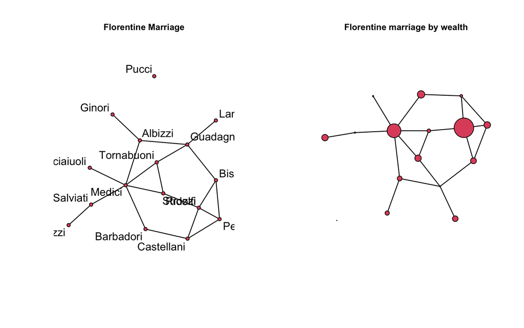

```r
plot(flomarriage,
     vertex.cex=wealth/25, # Make vertex size proportional to wealth attribute
     main="Florentine marriage by wealth", cex.main=0.8)
```

### The `summary` and `ergm` functions, and supporting functions

We’ll start by running some simple models to demonstrate the most commonly used functions for ERG modeling.

The syntax for specifying a model in the `ergm` package follows **R**’s formula convention:

$$\mbox{my.network} \sim
\mbox{my.model.terms}$$

This syntax is used for both the `summary` and `ergm` functions. The `summary` function simply returns the numerical values of the network statistics in the model. The `ergm` function estimates the model with those statistics.

It is good practice to run a `summmary` command on any model before fitting it with `ergm`. This is the ERGM equivalent of performing some descriptive analysis on your covariates. This can help you make sure you understand what the term represents, and it can help to flag potential problems that will lead to poor modeling results. We will now demonstrate the `summary` and `ergm` commands using a simple model.

#### A Bernoulli (“Erds/Rényi”) model

We begin with a simple model, containing only one term that represents the total number of edges in the network, $\sum{y_{ij}}$. The name of this ergm-term is `edges`, and when included in an ERGM its coefficient controls the overall density of the network.

```r
summary(flomarriage ~ edges) # Calculate the edges statistic for this network
```

```
edges
   20
```

```r
flomodel.01 <- ergm(flomarriage ~ edges) # Estimate the model
```

```
Starting maximum pseudolikelihood estimation (MPLE):
```

```
Evaluating the predictor and response matrix.
```

```
Maximizing the pseudolikelihood.
```

```
Finished MPLE.
```

```
Stopping at the initial estimate.
```

```
Evaluating log-likelihood at the estimate.
```

```r
summary(flomodel.01) # Look at the fitted model object
```

```
Call:
ergm(formula = flomarriage ~ edges)

Maximum Likelihood Results:

      Estimate Std. Error MCMC % z value Pr(>|z|)
edges  -1.6094     0.2449      0  -6.571   <1e-04 ***
---
Signif. codes:  0 '***' 0.001 '**' 0.01 '*' 0.05 '.' 0.1 ' ' 1

     Null Deviance: 166.4  on 120  degrees of freedom
 Residual Deviance: 108.1  on 119  degrees of freedom

AIC: 110.1  BIC: 112.9  (Smaller is better. MC Std. Err. = 0)
```

This simple model specifies a single homogeneous probability for all ties, which is captured by the coefficient of the `edges` term. How should we interpret the above estimate $\hat\theta$ of this coefficient? The easiest way is to return to the logit form of the ERGM. The log-odds that a tie—*any* tie, since the change statistic for the `edges` term equals one for all $y_{ij}$—is present is
$$\begin{align*}
\operatorname{logit}(p) &= \hat\theta \times \delta_{ij}(y) \\
& = -1.61 \times \mbox{change in $g(y)$ when
$y_{ij}$ goes from 0 to 1}\\
& = -1.61 \times 1.
\end{align*}$$
Do you see why $\delta_{ij}(y)=1$ no matter which $i$ and $j$ you specify?

To convert $\mbox{logit}(p)$ to $p$, we take the inverse logit of $\hat\theta$:
$$\begin{align*}
& = \exp(-1.61)/
(1+\exp(-1.61))\\
& = 0.167
\end{align*}$$
This probability corresponds to the density we observe in the flomarriage network: there are $20$ ties and $\binom{16}{2} = (16 \times 15)/2 = 120$ dyads, so the density of ties is $20/120 = 0.167$.

#### Triad formation

Let’s add a term often thought to be a measure of “clustering”: the number of completed triangles in the network, or $\frac13\sum{y_{ij}y_{ik}y_{jk}}$. The name for this ergm-term is `triangle`.

This is an example of a dyad dependent term, as the status of any triangle containing dyad $y_{ij}$ depends on the status of dyads of the form $y_{ik}$ and $y_{jk}$. This means that any model containing the ergm-term `triangle` has the property that dyads are not probabilistically independent of one another. As a result, `ergm` automatically uses its stochastic MCMC-based estimation algoirthm, so your results may differ slightly unless you use the same `set.seed` value:

```r
set.seed(321)
summary(flomarriage~edges+triangle) # Look at the g(y) statistics for this model
```

```
   edges triangle
      20        3
```

```r
flomodel.02 <- ergm(flomarriage~edges+triangle) # Estimate the theta coefficients
summary(flomodel.02)
```

```
Call:
ergm(formula = flomarriage ~ edges + triangle)

Monte Carlo Maximum Likelihood Results:

         Estimate Std. Error MCMC % z value Pr(>|z|)
edges     -1.6900     0.3620      0  -4.668   <1e-04 ***
triangle   0.1901     0.5982      0   0.318    0.751
---
Signif. codes:  0 '***' 0.001 '**' 0.01 '*' 0.05 '.' 0.1 ' ' 1

     Null Deviance: 166.4  on 120  degrees of freedom
 Residual Deviance: 108.1  on 118  degrees of freedom

AIC: 112.1  BIC: 117.6  (Smaller is better. MC Std. Err. = 0.01102)
```

Now, how should we interpret coefficients?

The conditional log-odds of two actors having a tie, keeping the rest of the network fixed, is
$$-1.69 \times\mbox{change in the number of ties} + 0.19
\times\mbox{change in number of triangles.}$$

- For a tie that will create no triangles, the conditional log-odds is $-1.69$.
- For a tie that will create one triangle: $-1.69 + 0.19 = -1.5$
- For a tie that will create two triangles: $-1.69 + 2 \times0.19 = -1.31$
- the corresponding probabilities are shown here (note the use of the `plogis` and `coef` functions):

```r
plogis(coef(flomodel.02)[[1]] + (0:2) * coef(flomodel.02)[[2]])
```

```
[1] 0.1557799 0.1824455 0.2125265
```

Let’s take a closer look at the ergm object that the function outputs:

```r
class(flomodel.02) # this has the class ergm
```

```
[1] "ergm"
```

```r
names(flomodel.02) # the ERGM object contains lots of components.
```

```
 [1] "coefficients"    "sample"          "sample.obs"      "iterations"
 [5] "MCMCtheta"       "loglikelihood"   "gradient"        "hessian"
 [9] "covar"           "failure"         "network"         "newnetworks"
[13] "newnetwork"      "coef.init"       "est.cov"         "coef.hist"
[17] "stats.hist"      "steplen.hist"    "control"         "etamap"
[21] "call"            "ergm_version"    "MPLE_is_MLE"     "formula"
[25] "nw.stats"        "constrained"     "constraints"     "obs.constraints"
[29] "reference"       "estimate"        "estimate.desc"   "offset"
[33] "drop"            "estimable"       "null.lik"        "mle.lik"
```

```r
coef(flomodel.02) # you can extract/inspect individual components
```

```
    edges  triangle
-1.689969  0.190103
```

#### Nodal covariates: effects on mean degree

We saw earlier that wealth appeared to be associated with higher degree in this network. We can use `ergm` to test this. Wealth is a nodal covariate, so we use the ergm-term **nodecov**.

```r
summary(wealth) # summarize the distribution of wealth
```

```
   Min. 1st Qu.  Median    Mean 3rd Qu.    Max.
   3.00   17.50   39.00   42.56   48.25  146.00
```

```r
# plot(flomarriage,
#      vertex.cex=wealth/25,
#      main="Florentine marriage by wealth",
#      cex.main=0.8) # network plot with vertex size proportional to wealth
summary(flomarriage~edges+nodecov('wealth')) # observed statistics for the model
```

```
         edges nodecov.wealth
            20           2168
```

```r
flomodel.03 <- ergm(flomarriage~edges+nodecov('wealth'))
```

```
Starting maximum pseudolikelihood estimation (MPLE):
```

```
Evaluating the predictor and response matrix.
```

```
Maximizing the pseudolikelihood.
```

```
Finished MPLE.
```

```
Stopping at the initial estimate.
```

```
Evaluating log-likelihood at the estimate.
```

```r
summary(flomodel.03)
```

```
Call:
ergm(formula = flomarriage ~ edges + nodecov("wealth"))

Maximum Likelihood Results:

                Estimate Std. Error MCMC % z value Pr(>|z|)
edges          -2.594929   0.536056      0  -4.841   <1e-04 ***
nodecov.wealth  0.010546   0.004674      0   2.256   0.0241 *
---
Signif. codes:  0 '***' 0.001 '**' 0.01 '*' 0.05 '.' 0.1 ' ' 1

     Null Deviance: 166.4  on 120  degrees of freedom
 Residual Deviance: 103.1  on 118  degrees of freedom

AIC: 107.1  BIC: 112.7  (Smaller is better. MC Std. Err. = 0)
```

And yes, there is a significant positive wealth effect on the probability of a tie.

What does the value of the **nodecov** statistic represent, and how should we interpret the coefficients here? The wealth effect operates on both nodes in a dyad. The conditional log-odds of a tie between two actors is
$$\small{
-2.59\times\mbox{change in the number of ties} + 0.01\times\mbox{the
wealth of node 1} + 0.01\times\mbox{the wealth of node 2}
},$$
or
$$\small{
-2.59 + 0.01\times\mbox{the sum of the wealth of the two nodes}
}.$$

- for a tie between two nodes with minimum wealth, the conditional log-odds is  
  $-2.59 + 0.01*(3+3) = -2.53$
- for a tie between two nodes with maximum wealth:  
  $-2.59 + 0.01*(146+146) = 0.33$
- for a tie between the node with maximum wealth and the node with minimum wealth:  
  $-2.59 + 0.01*(146+3) = -1.1$
- The corresponding probabilities are 0.07, 0.58, and 0.25.

This model specification does not include a term for homophily by wealth, i.e., a term accounting for similarity in wealth of the two end nodes of a potential tie. It just specifies a relation between wealth and mean degree. To specify homophily on wealth, you could use the ergm-term `absdiff`. See section 3 below for more information on ergm-terms.

#### Nodal covariates: Homophily

Let’s try a larger network, a simulated mutual friendship network based on one of the schools from the AddHealth study. Here, we’ll examine the homophily in friendships by grade and race. Both are discrete attributes so we use the ergm-term `nodematch`.

```r
data(faux.mesa.high)
mesa <- faux.mesa.high
```

```r
set.seed(1)
mesa
```

```
 Network attributes:
  vertices = 205
  directed = FALSE
  hyper = FALSE
  loops = FALSE
  multiple = FALSE
  bipartite = FALSE
  total edges= 203
    missing edges= 0
    non-missing edges= 203

 Vertex attribute names:
    Grade Race Sex

No edge attributes
```

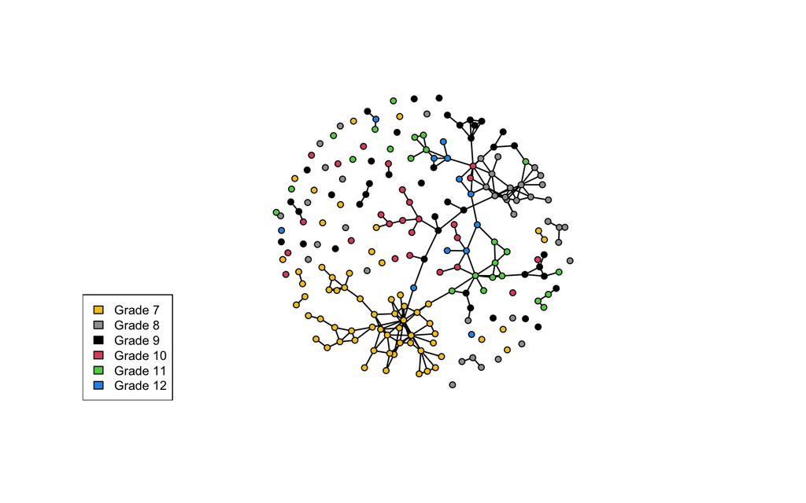

```r
par(mfrow=c(1,1)) # Back to 1-panel plots
plot(mesa, vertex.col='Grade')
legend('bottomleft',fill=7:12,
       legend=paste('Grade',7:12),cex=0.75)
```

```r
fauxmodel.01 <- ergm(mesa ~edges +
        nodefactor('Grade') + nodematch('Grade',diff=T) +
        nodefactor('Race') + nodematch('Race',diff=T))
```

```
Observed statistic(s) nodematch.Race.Black and nodematch.Race.Other are at their smallest attainable values. Their coefficients will be fixed at -Inf.
```

```
Starting maximum pseudolikelihood estimation (MPLE):
```

```
Evaluating the predictor and response matrix.
```

```
Maximizing the pseudolikelihood.
```

```
Finished MPLE.
```

```
Stopping at the initial estimate.
```

```
Evaluating log-likelihood at the estimate.
```

```r
summary(fauxmodel.01)
```

```
Call:
ergm(formula = mesa ~ edges + nodefactor("Grade") + nodematch("Grade",
    diff = T) + nodefactor("Race") + nodematch("Race", diff = T))

Maximum Likelihood Results:

                      Estimate Std. Error MCMC % z value Pr(>|z|)
edges                  -8.0538     1.2561      0  -6.412  < 1e-04 ***
nodefactor.Grade.8      1.5201     0.6858      0   2.216 0.026663 *
nodefactor.Grade.9      2.5284     0.6493      0   3.894  < 1e-04 ***
nodefactor.Grade.10     2.8652     0.6512      0   4.400  < 1e-04 ***
nodefactor.Grade.11     2.6291     0.6563      0   4.006  < 1e-04 ***
nodefactor.Grade.12     3.4629     0.6566      0   5.274  < 1e-04 ***
nodematch.Grade.7       7.4662     1.1730      0   6.365  < 1e-04 ***
nodematch.Grade.8       4.2882     0.7150      0   5.997  < 1e-04 ***
nodematch.Grade.9       2.0371     0.5538      0   3.678 0.000235 ***
nodematch.Grade.10      1.2489     0.6233      0   2.004 0.045111 *
nodematch.Grade.11      2.4521     0.6124      0   4.004  < 1e-04 ***
nodematch.Grade.12      1.2987     0.6981      0   1.860 0.062824 .
nodefactor.Race.Hisp   -1.6659     0.2963      0  -5.622  < 1e-04 ***
nodefactor.Race.NatAm  -1.4725     0.2869      0  -5.132  < 1e-04 ***
nodefactor.Race.Other  -2.9618     1.0372      0  -2.856 0.004296 **
nodefactor.Race.White  -0.8488     0.2958      0  -2.869 0.004112 **
nodematch.Race.Black      -Inf     0.0000      0    -Inf  < 1e-04 ***
nodematch.Race.Hisp     0.6912     0.3451      0   2.003 0.045153 *
nodematch.Race.NatAm    1.2482     0.3550      0   3.517 0.000437 ***
nodematch.Race.Other      -Inf     0.0000      0    -Inf  < 1e-04 ***
nodematch.Race.White    0.3140     0.6405      0   0.490 0.623947
---
Signif. codes:  0 '***' 0.001 '**' 0.01 '*' 0.05 '.' 0.1 ' ' 1

     Null Deviance: 28958  on 20910  degrees of freedom
 Residual Deviance:  1798  on 20889  degrees of freedom

AIC: 1836  BIC: 1987  (Smaller is better. MC Std. Err. = 0)

 Warning: The following terms have infinite coefficient estimates:
  nodematch.Race.Black nodematch.Race.Other
```

Two of the coefficients are estimated as `-Inf` (the nodematch coefficients for race Black and Other). Why is this?

```r
table(mesa %v% 'Race') # Frequencies of race
```

```
Black  Hisp NatAm Other White
    6   109    68     4    18
```

```r
mixingmatrix(mesa, "Race")
```

```
      Black Hisp NatAm Other White
Black     0    8    13     0     5
Hisp      8   53    41     1    22
NatAm    13   41    46     0    10
Other     0    1     0     0     0
White     5   22    10     0     4
```

```
Note:  Marginal totals can be misleading for undirected mixing matrices.
```

We see that there are very few students in the Black and Other race categories, and these few students form no within-group ties. The empty cells are what produce the -Inf estimates.

We would have caught this earlier if we had looked at the $g(y)$ statistics at the beginning:

```r
summary(mesa ~edges  +
          nodefactor('Grade') + nodematch('Grade',diff=T) +
          nodefactor('Race') + nodematch('Race',diff=T))
```

```
                edges    nodefactor.Grade.8    nodefactor.Grade.9
                  203                    75                    65
  nodefactor.Grade.10   nodefactor.Grade.11   nodefactor.Grade.12
                   36                    49                    28
    nodematch.Grade.7     nodematch.Grade.8     nodematch.Grade.9
                   75                    33                    23
   nodematch.Grade.10    nodematch.Grade.11    nodematch.Grade.12
                    9                    17                     6
 nodefactor.Race.Hisp nodefactor.Race.NatAm nodefactor.Race.Other
                  178                   156                     1
nodefactor.Race.White  nodematch.Race.Black   nodematch.Race.Hisp
                   45                     0                    53
 nodematch.Race.NatAm  nodematch.Race.Other  nodematch.Race.White
                   46                     0                     4
```

**Moral**: It is often helpful to check the descriptive statistics of a model in the observed network before fitting the model.

See also the ergm-term `nodemix` for fitting mixing patterns other than homophily on discrete nodal attributes.

#### Directed ties

Let’s try a model for a directed network and examine the tendency for ties to be reciprocated (“mutuality”). The ergm-term for the corresponding statistic is `mutual`. We’ll fit this model to the third wave of the classic Sampson Monastery data, and we’ll start by taking a look at the network.

```r
set.seed(2)
data(samplk) # directed data: Sampson's Monks
ls()
```

```
 [1] "faux.mesa.high" "fauxmodel.01"   "flobusiness"    "flomarriage"
 [5] "flomodel.01"    "flomodel.02"    "flomodel.03"    "mesa"
 [9] "samplk1"        "samplk2"        "samplk3"        "wealth"
```

```r
samplk3
```

```
 Network attributes:
  vertices = 18
  directed = TRUE
  hyper = FALSE
  loops = FALSE
  multiple = FALSE
  bipartite = FALSE
  total edges= 56
    missing edges= 0
    non-missing edges= 56

 Vertex attribute names:
    cloisterville group vertex.names

No edge attributes
```

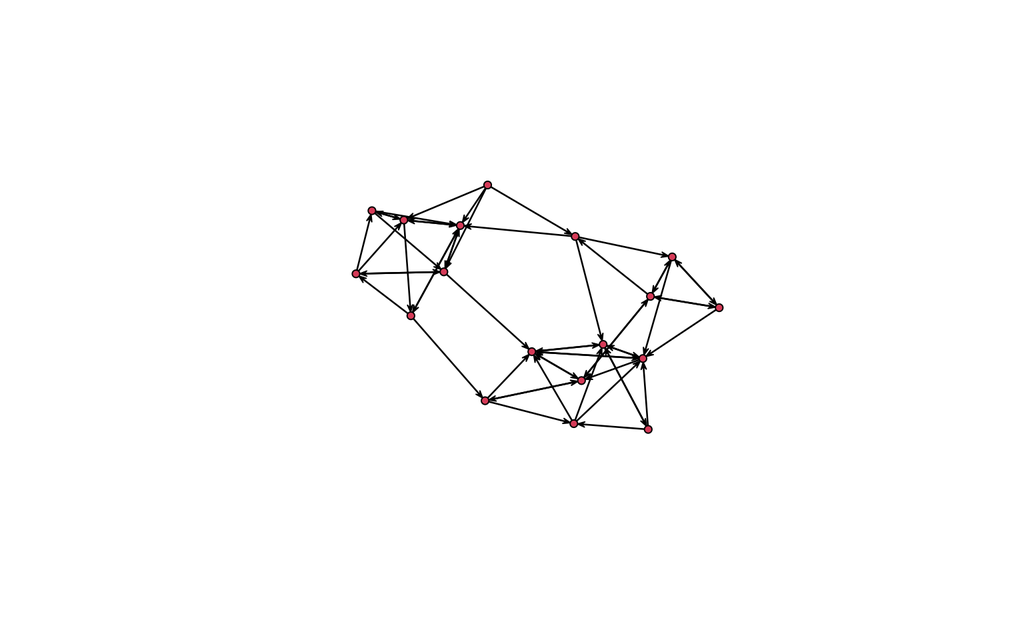

```r
plot(samplk3)
```

```r
summary(samplk3~edges+mutual)
```

```
 edges mutual
    56     15
```

The plot now shows the direction of a tie, and the $g(y)$ statistics for this model in this network are 56 total ties and 15 mutual dyads. This means 30 of the 56 ties are reciprocated, i.e., they are part of dyads in which both directional ties are present.

```r
set.seed(3)
sampmodel.01 <- ergm(samplk3~edges+mutual)
summary(sampmodel.01)
```

```
Call:
ergm(formula = samplk3 ~ edges + mutual)

Monte Carlo Maximum Likelihood Results:

       Estimate Std. Error MCMC % z value Pr(>|z|)
edges   -2.1639     0.2211      0  -9.789   <1e-04 ***
mutual   2.3118     0.4860      0   4.757   <1e-04 ***
---
Signif. codes:  0 '***' 0.001 '**' 0.01 '*' 0.05 '.' 0.1 ' ' 1

     Null Deviance: 424.2  on 306  degrees of freedom
 Residual Deviance: 268.1  on 304  degrees of freedom

AIC: 272.1  BIC: 279.6  (Smaller is better. MC Std. Err. = 0.3199)
```

There is a statistically significant mutuality effect. The coefficients for the edges and mutual terms add to roughly zero for a mutual tie, so the conditional log-odds of a mutual tie are about zero. Thus, the conditional probability that a tie exists, given that the tie in the reverse direction exists, is about 50%. (Do you see why a log-odds of zero corresponds to a probability of 50%?) By contrast, a non-mutual tie has a conditional log-odds of -2.16, or 10% probability.

Triangle terms in directed networks can have many different configurations. Many of these configurations are coded as ergm-terms, and we’ll talk about these more below.

## 2. Missing data

It is important to distinguish between the absence of a tie and the absence of data on whether a tie exists. The former is an observed zero, whereas the latter is unobserved. We should not code both of these as “0”. The `ergm` package recognizes and handles missing data appropriately, as long as we identify the data as missing. Let’s explore this with a simple example.

Start by estimating an ergm on a 10-node network with three missing ties.

```r
set.seed(4)
missnet <- network.initialize(10,directed=F) # initialize an empty net with 10 nodes
missnet[1,2] <- missnet[2,7] <- missnet[3,6] <- 1 # add a few ties
missnet[4,6] <- missnet[4,9] <- missnet[5,6] <- NA # mark a few dyads missing
summary(missnet)
```

```
Network attributes:
  vertices = 10
  directed = FALSE
  hyper = FALSE
  loops = FALSE
  multiple = FALSE
  bipartite = FALSE
 total edges = 6
   missing edges = 3
   non-missing edges = 3
 density = 0.06666667

Vertex attributes:
  vertex.names:
   character valued attribute
   10 valid vertex names

No edge attributes

Network adjacency matrix:
   1 2 3  4  5  6 7 8  9 10
1  0 1 0  0  0  0 0 0  0  0
2  1 0 0  0  0  0 1 0  0  0
3  0 0 0  0  0  1 0 0  0  0
4  0 0 0  0  0 NA 0 0 NA  0
5  0 0 0  0  0 NA 0 0  0  0
6  0 0 1 NA NA  0 0 0  0  0
7  0 1 0  0  0  0 0 0  0  0
8  0 0 0  0  0  0 0 0  0  0
9  0 0 0 NA  0  0 0 0  0  0
10 0 0 0  0  0  0 0 0  0  0
```

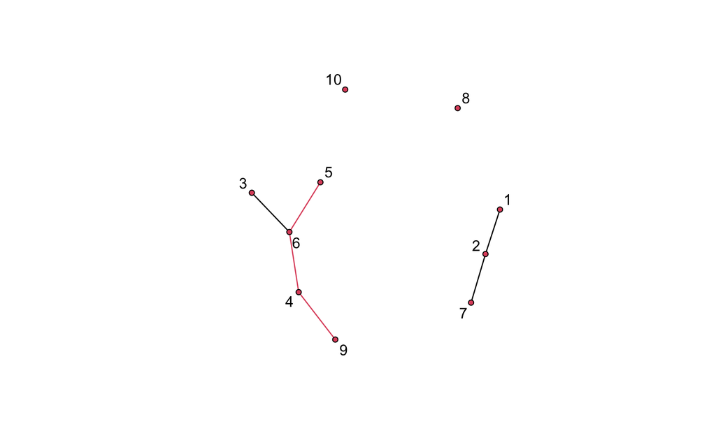

```r
# plot missnet with missing dyads colored red.
tempnet <- missnet
tempnet[4,6] <- tempnet[4,9] <- tempnet[5,6] <- 1
missnetmat <- as.matrix(missnet)
missnetmat[is.na(missnetmat)] <- 2
plot(tempnet,label = network.vertex.names(tempnet),
     edge.col = missnetmat)
```

```r
# fit an ergm to the network with missing data identified
summary(missnet~edges)
```

```
edges
    3
```

```r
summary(ergm(missnet~edges))
```

```
Starting maximum pseudolikelihood estimation (MPLE):
```

```
Evaluating the predictor and response matrix.
```

```
Maximizing the pseudolikelihood.
```

```
Finished MPLE.
```

```
Stopping at the initial estimate.
```

```
Evaluating log-likelihood at the estimate.
```

```
Call:
ergm(formula = missnet ~ edges)

Maximum Likelihood Results:

      Estimate Std. Error MCMC % z value Pr(>|z|)
edges  -2.5649     0.5991      0  -4.281   <1e-04 ***
---
Signif. codes:  0 '***' 0.001 '**' 0.01 '*' 0.05 '.' 0.1 ' ' 1

     Null Deviance: 58.22  on 42  degrees of freedom
 Residual Deviance: 21.61  on 41  degrees of freedom

AIC: 23.61  BIC: 25.35  (Smaller is better. MC Std. Err. = 0)
```

The coefficient estimate equals -2.56, which corresponds to a probability of 7.14%. Our network has 3 ties, out of the 42 non-missing nodal pairs (10 choose 2 minus 3), and 3/42 = 7.14%. So our estimate represents the density of ties in the observed sample.

Now let’s assign those missing ties the (observed) value “0” and check how the value of the coefficient will change. Can you predict whether it will get bigger or smaller? Can you calculate it directly before checking the output of an `ergm` fit?

```r
missnet_bad <- missnet # create network with missing dyads set to 0
missnet_bad[4,6] <- missnet_bad[4,9] <- missnet_bad[5,6] <- 0

# fit an ergm to the network with missing dyads set to 0
summary(missnet_bad)
```

```
Network attributes:
  vertices = 10
  directed = FALSE
  hyper = FALSE
  loops = FALSE
  multiple = FALSE
  bipartite = FALSE
 total edges = 3
   missing edges = 0
   non-missing edges = 3
 density = 0.06666667

Vertex attributes:
  vertex.names:
   character valued attribute
   10 valid vertex names

No edge attributes

Network adjacency matrix:
   1 2 3 4 5 6 7 8 9 10
1  0 1 0 0 0 0 0 0 0  0
2  1 0 0 0 0 0 1 0 0  0
3  0 0 0 0 0 1 0 0 0  0
4  0 0 0 0 0 0 0 0 0  0
5  0 0 0 0 0 0 0 0 0  0
6  0 0 1 0 0 0 0 0 0  0
7  0 1 0 0 0 0 0 0 0  0
8  0 0 0 0 0 0 0 0 0  0
9  0 0 0 0 0 0 0 0 0  0
10 0 0 0 0 0 0 0 0 0  0
```

```r
summary(ergm(missnet_bad~edges))
```

```
Starting maximum pseudolikelihood estimation (MPLE):
```

```
Evaluating the predictor and response matrix.
```

```
Maximizing the pseudolikelihood.
```

```
Finished MPLE.
```

```
Stopping at the initial estimate.
```

```
Evaluating log-likelihood at the estimate.
```

```
Call:
ergm(formula = missnet_bad ~ edges)

Maximum Likelihood Results:

      Estimate Std. Error MCMC % z value Pr(>|z|)
edges  -2.6391     0.5976      0  -4.416   <1e-04 ***
---
Signif. codes:  0 '***' 0.001 '**' 0.01 '*' 0.05 '.' 0.1 ' ' 1

     Null Deviance: 62.38  on 45  degrees of freedom
 Residual Deviance: 22.04  on 44  degrees of freedom

AIC: 24.04  BIC: 25.85  (Smaller is better. MC Std. Err. = 0)
```

The coefficient is smaller now because the missing ties are counted as “0”, and this translates to a conditional tie probability of 6.67%, or 3/45.

MORAL: If you have missing data on ties, be sure to identify them by assigning the “NA” code. This is particularly important if you’re reading in data as an edgelist, as all dyads without edges are implicitly set to “0” in this case.

## 3. Model terms available for *ergm* estimation and simulation

Model terms are the expressions (e.g., `edges` and `triangle`) used to represent predictors on the right-hand side of formulas used in:

- calls to `summary` (to obtain measurements of network statistics on a dataset)
- calls to `ergm` (to estimate, or fit, an ERGM’s coefficients)
- calls to `simulate` (to simulate networks from a fitted ERGM)

Because these terms are not exogeneous measures, but functions of the dyad states in the network, they must be calculated for the network that is being modeled. Many ERGM terms are simple counts of configurations (e.g., edges, nodal degrees, stars, triangles), but others are more complex functions of these configurations (e.g., geometrically weighted degrees and shared partners). In theory, any configuration or function of configurations can be a term in an ERGM. In practice, however, these terms have to be constructed before they can be used—that is, one has to explicitly write an algorithm that defines and calculates the network statistic of interest. This is another key way that ERGMs differ from traditional linear and general linear models.

The terms that can be used in a model also depend on the type of network being analyzed: directed or undirected, one-mode or two-mode (“bipartite”), binary or valued edges.

### Terms provided with ergm

The `ergm` package provides myriad terms, and it can be difficult to absorb the full array of available model terms in any one place. This is particularly true with the release of `ergm` version 4.0, which expands the user’s ability to create terms even further, for example through the use of term operators. As mentioned above in Section 1, it is possible to search for specific topics using `search.ergmTerms`; to obtain help on a particular term called `[name]` using `ergmTerm?[name]`, where `[name]` is the name of the term; or to see the full list of available terms using `?ergmTerm`.

The list of all terms is quite lengthy, so it may be helpful to start with a more concise list such as the one found [here](https://statnet.github.io/nme/d2-ergmterms.html). A more detailed discussion can be found in [volume 24, issue 4 of the *Journal of Statistical Software*](http://www.jstatsoft.org/v24/i04).

To appreciate the expanded capabilities of the `ergm` package as of the release of version 4.0, we recommend [Krivitsky et al (2021)](https://arxiv.org/abs/2106.04997). In this article, Section 3 describes the enhanced flexibility to create specialized model terms involving functions of nodal covariates, and Section 4 explains how operators further extend the types of terms at the user’s disposal.

### Coding new ergm-terms

There is a `statnet` package called `ergm.userterms` that provides the utilities needed to write new ergm-terms. The package is available via GitHub at https://github.com/statnet/ergm.userterms, and installing it will include the tutorial, called ergmuserterms.pdf. A tutorial can also be found in the [*Journal of Statistical Software 52(2)*](http://www.jstatsoft.org/v52/i02), and some introductory slides and installation instructions from the workshop we teach on coding ergm-terms can be found [on GitHub](https://statnet.org/workshop-ergm-userterms/).

Writing up new `ergm` terms requires some knowledge of C and the ability to build R from source.

## 4. Assessing convergence for dyad dependent models: MCMC Diagnostics

When dyad dependent terms are in the model, the computational algorithms in `ergm` use Markov chain Monte Carlo (MCMC) to estimate the parameters. This approach basically works as follows:

- Start with an initial vector of coefficient values; the default is to use the maximum psuedo-likelihood estimate, or MPLE. (We do not cover MPLE in this tutorial, but this estimator is easy to compute using a standard logistic regression algorithm.)
- Choose a dyad at random, and flip a coin, weighted by the model, to decide whether there will be a tie.
- Repeat this for 1024 steps, the default control value of `MCMC.interval` (see `?control.simulate`)
- Calculate and store the $g(y)$ statistics for the resulting network.
- Repeat this process until either `MCMC.samplesize` vectors of statistics have been collected, or until a certain `MCMC.effectiveSize` criterion is reached (see `?control.simulate`).
- Calculate the sample average of the sampled $g(y)$ statistics, then compare this to the vector of observed statistics.
- Update the coefficient estimates as needed.
- Repeat until the process converges: The difference between the MCMC sample average and the observed statistic is sufficiently small.

For these models, it is important to assess model convergence before interpreting the model results, i.e., before evaluating statistical significance, interpreting coefficients, or assessing goodness of fit. To do this, we use the function `mcmc.diagnostics`, as we now demonstrate.

### What it looks like when a model converges properly

We will first consider a simple dyadic dependent model where the algorithm works using the program defaults, with a degree(1) term that captures whether there are more (or less) degree 1 nodes than we would expect, given the density.

```r
set.seed(314159)
summary(flobusiness~edges+degree(1))
```

```
  edges degree1
     15       3
```

```r
fit <- ergm(flobusiness~edges+degree(1))
summary(fit)
```

```
Call:
ergm(formula = flobusiness ~ edges + degree(1))

Monte Carlo Maximum Likelihood Results:

        Estimate Std. Error MCMC % z value Pr(>|z|)
edges    -2.1177     0.3032      0  -6.984   <1e-04 ***
degree1  -0.6272     0.6010      0  -1.044    0.297
---
Signif. codes:  0 '***' 0.001 '**' 0.01 '*' 0.05 '.' 0.1 ' ' 1

     Null Deviance: 166.36  on 120  degrees of freedom
 Residual Deviance:  89.39  on 118  degrees of freedom

AIC: 93.39  BIC: 98.96  (Smaller is better. MC Std. Err. = 0.03364)
```

```r
mcmc.diagnostics(fit)
```

```
Sample statistics summary:

Iterations = 7168:131072
Thinning interval = 512
Number of chains = 1
Sample size per chain = 243

1. Empirical mean and standard deviation for each variable,
   plus standard error of the mean:

           Mean    SD Naive SE Time-series SE
edges    0.2140 3.601   0.2310         0.2310
degree1 -0.1276 1.817   0.1166         0.1166

2. Quantiles for each variable:

        2.5% 25% 50% 75% 97.5%
edges     -8  -2   1   2     7
degree1   -3  -1   0   1     4


Are sample statistics significantly different from observed?
               edges    degree1 Overall (Chi^2)
diff.      0.2139918 -0.1275720              NA
test stat. 0.9262347 -1.0944112       1.4827084
P-val.     0.3543240  0.2737747       0.4790184

Sample statistics cross-correlations:
             edges    degree1
edges    1.0000000 -0.3929828
degree1 -0.3929828  1.0000000

Sample statistics auto-correlation:
Chain 1
                edges     degree1
Lag 0     1.000000000  1.00000000
Lag 512  -0.018373256  0.06527360
Lag 1024 -0.008853872 -0.00419178
Lag 1536 -0.006593784 -0.05395258
Lag 2048  0.033260731  0.02580333
Lag 2560 -0.059894956  0.02109630

Sample statistics burn-in diagnostic (Geweke):
Chain 1

Fraction in 1st window = 0.1
Fraction in 2nd window = 0.5

  edges degree1
 1.3769  0.1355

Individual P-values (lower = worse):
    edges   degree1
0.1685490 0.8922124
Joint P-value (lower = worse):  0.1257365 .
```

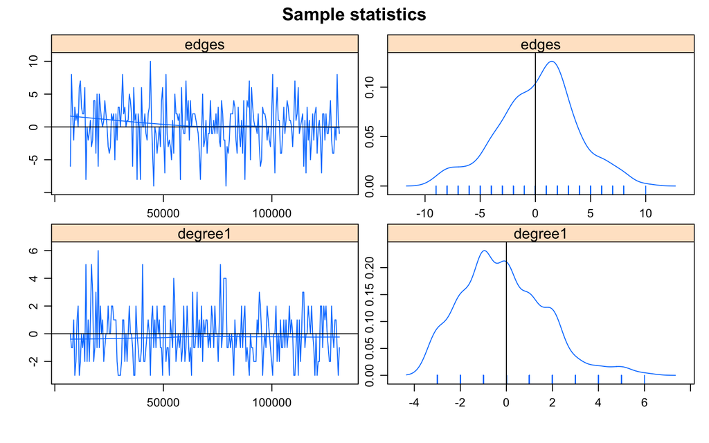

[output not shown]

What this shows is a summary of the statistics generated by the MCMC process, with each row summarizing a different statistic and with each statistic measured in terms of its value relative to the corresponding value for the original observed network. On the left is a “traceplot” in which the values are plotted as a function of iteration number; while on the right is a histogram-like plot of the whole sample of statistics without regard to their order in the MCMC process.

This example exhibits the sort of behavior that we want to see in the MCMC diagnostics: The MCMC sample statistics are varying randomly around the observed values at each step; we might say that the chain is “mixing well”. The sampled values show little serial correlation, indicating that they are independent draws, and they have a roughly bell-shaped distribution, centered at zero. The sawtooth pattern visible in the degree term deviation plot is due to the combination of discrete values and small range in the statistics: the observed number of degree 1 nodes is 3, and only a few discrete values are produced by the simulations. So the sawtooth pattern is is an inherent property of the statistic, not a problem with the model.

There are many control parameters for the MCMC algorithm (`help(snctrl)`), and we’ll play with some of these below. To see what the algorithm is doing at each step, we can drop the sampling interval down to 1:

```r
set.seed(271828)
fit <- ergm(flobusiness~edges+degree(1),
            control=snctrl(MCMC.interval=1))
```

This runs an MCMC algorithm where every network’s statistics are returned, which might be useful if we are trying to debug a bad model fit.

In the last section we’ll look at some models that don’t converge properly, and how to use MCMC diagnostics to identify and address this.

## 5. Network simulation: the *simulate* command and *network.list* objects

Once we have estimated the coefficients of an ERGM, the model is completely specified. It defines a probability distribution across all networks on the given set of nodes. If the model is a good fit to the observed data, then networks drawn from this distribution will be more likely to “resemble” the observed data. Thus, one way we use simulations from a model is to assess that model’s goodness of fit to our data. Here, we will take a quick look at how the simulation function works.

The `simulate` command is easy to run if we have an ERGM that has already been fitted. Let’s use the `flomodel.03` object from earlier:

```r
set.seed(101)
flomodel.03.sim <- simulate(flomodel.03,nsim=10)
class(flomodel.03.sim) # Reveal the class of the object created
```

```
[1] "network.list"
```

```r
summary(flomodel.03.sim) # quick summary of a network.list object
```

```
Number of Networks: 10
Model: flomarriage ~ edges + nodecov("wealth")
Reference: ~Bernoulli
Constraints: ~.
Stored network statistics:
      edges nodecov.wealth
 [1,]    17           1539
 [2,]    18           1742
 [3,]    21           2471
 [4,]    16           1304
 [5,]    18           1779
 [6,]    26           3143
 [7,]    22           2239
 [8,]    26           2905
 [9,]    24           2792
[10,]    15           1682
attr(,"monitored")
[1] FALSE FALSE
```

```
Number of Networks: 10
Model: flomarriage ~ edges + nodecov("wealth")
Reference: ~Bernoulli
Constraints: ~.
```

```r
attributes(flomodel.03.sim) # Reveal the various attributes of this network.list
```

```
$coefficients
         edges nodecov.wealth
   -2.59492903     0.01054591

$control
Control parameter list generated by 'control.simulate.formula' or equivalent. Non-empty parameters:
MCMC.burnin: 16384
MCMC.interval: 1024
MCMC.scale: 1
MCMC.prop: ~sparse
MCMC.prop.weights: "default"
MCMC.batch: 0
MCMC.effectiveSize.damp: 10
MCMC.effectiveSize.maxruns: 1000
MCMC.effectiveSize.burnin.pval: 0.2
MCMC.effectiveSize.burnin.min: 0.05
MCMC.effectiveSize.burnin.max: 0.5
MCMC.effectiveSize.burnin.nmin: 16
MCMC.effectiveSize.burnin.nmax: 128
MCMC.effectiveSize.burnin.PC: FALSE
MCMC.effectiveSize.burnin.scl: 1024
MCMC.maxedges: Inf
MCMC.runtime.traceplot: FALSE
network.output: "network"
parallel: 0
parallel.version.check: TRUE
parallel.inherit.MT: FALSE
MCMC.samplesize: 10
obs.MCMC.mul: 0.25
obs.MCMC.samplesize.mul: 0.5
obs.MCMC.interval.mul: 0.5
obs.MCMC.burnin.mul: 0.5
obs.MCMC.prop: ~sparse
obs.MCMC.prop.weights: "default"
MCMC.save_networks: TRUE

$response
[1] NA

$class
```

[output cut: 28 more lines]

```
    missing edges= 0
    non-missing edges= 20

 Vertex attribute names:
    priorates totalties vertex.names wealth

No edge attributes

$constraints
~.
<environment: 0x115440798>

$reference
~Bernoulli
<environment: 0x11546aea8>
```

We can check whether it appears that the simulated sample mean statistics are in fact close to the observed statistics:

```r
rbind("obs"=summary(flomarriage~edges+nodecov("wealth")),
      "sim mean"=colMeans(attr(flomodel.03.sim, "stats")))
```

```
         edges nodecov.wealth
obs       20.0         2168.0
sim mean  20.3         2159.6
```

By default, our `network.list` object contains all ten of the networks we simulated. If it were important to save memory, we could have asked that only the network statistics be stored by passing the `output="stats"` option to the earlier `simulate` command; see `?simulate.ergm` for more details. Let’s take a look at the seventh network in our list of ten:

```r
# we can also plot individual simulations
flomodel.03.sim[[7]]
```

```
 Network attributes:
  vertices = 16
  directed = FALSE
  hyper = FALSE
  loops = FALSE
  multiple = FALSE
  bipartite = FALSE
  total edges= 22
    missing edges= 0
    non-missing edges= 22

 Vertex attribute names:
    priorates totalties vertex.names wealth

No edge attributes
```

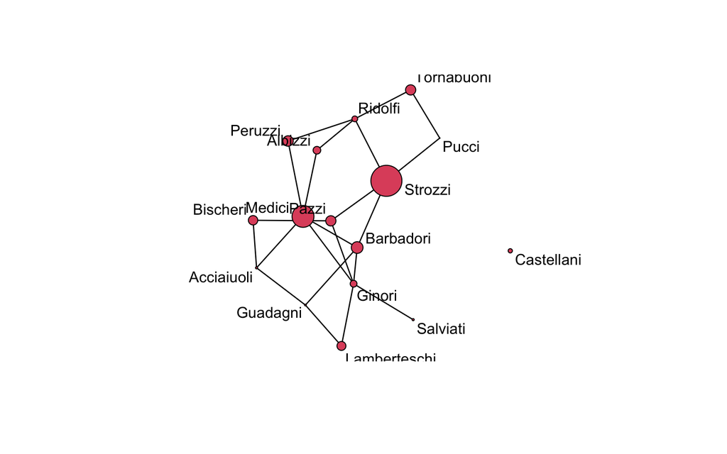

```r
plot(flomodel.03.sim[[7]],
     label= flomodel.03.sim[[7]] %v% "vertex.names",
     vertex.cex = (flomodel.03.sim[[7]] %v% "wealth")/25)
```

Voil`a. Your plot may look different since randomness is involved in both the simulation and in the plotting of a network.

Simulation from a model is a very powerful tool for examining the range of variation that can be expected from this model, both in the sufficient statistics that define the model and in other statistics not explicitly specified by the model. Simulation plays a large role in analyizing egocentrically sampled data, and if you take the `tergm` workshop, you will see how we can use simulation to examine the temporal implications of a model based on a single cross-sectional egocentrically sampled dataset.

Next, we will examine a primary use of simulation in the `ergm` package: we simulate networks from a fitted model to evaluate goodness of fit to the observed network.

## 6. Examining the quality of model fit — GOF

ERGMs can be seen as generative models when they represent the process that governs the global patterns of tie prevalence from a local perspective, i.e., the perspective of the nodes involved in the particular micro-configurations represented by the ergm-terms in the model. The locally generated processes in turn aggregate to produce characteristic global network properties, even those global properties that are not explicit terms in the model.

One test of whether an ERGM fits the data is therefore how well it reproduces observed global network properties *that are not in the model*. We do this by using the `gof` function to choose network statistics that are not in the model, then compare the values of these statistics observed in the original network to the distribution of values we get in simulated networks from our model.

The `gof` function is a bit different than the `summary`, `ergm`, and `simulate` functions, in that it currently (for undirected networks) only takes three ergm-terms as arguments: `degree`, `espartners` (edgewise shared partners), and `distance` (geodesic distances). Each of these terms captures an aggregate network distribution at either the node level (`degree`), the edge level (`espartners`), or the dyad level (`distance`).

```r
set.seed(54321) # The gof function uses random values
flomodel.03.gof <- gof(flomodel.03)
flomodel.03.gof
```

```
Goodness-of-fit for degree

         obs min mean max MC p-value
degree0    1   0 1.20   5       1.00
degree1    4   0 3.64   8       1.00
degree2    2   0 3.98   9       0.44
degree3    6   0 3.43   7       0.20
degree4    2   0 1.86   7       1.00
degree5    0   0 1.03   5       0.68
degree6    1   0 0.48   4       0.70
degree7    0   0 0.24   2       1.00
degree8    0   0 0.11   1       1.00
degree9    0   0 0.02   1       1.00
degree10   0   0 0.01   1       1.00

Goodness-of-fit for edgewise shared partner

     obs min  mean max MC p-value
esp0  12   5 12.65  19       0.86
esp1   7   0  5.49  15       0.72
esp2   1   0  1.71   8       1.00
esp3   0   0  0.22   5       1.00
esp4   0   0  0.03   2       1.00

Goodness-of-fit for minimum geodesic distance

    obs min  mean max MC p-value
1    20  13 20.10  37       1.00
2    35  17 35.34  67       1.00
3    32  11 27.79  41       0.58
4    15   2 12.20  26       0.76
5     3   0  3.68  13       0.94
6     0   0  0.88  11       1.00
7     0   0  0.19   8       1.00
8     0   0  0.03   2       1.00
Inf  15   0 19.79  65       1.00

Goodness-of-fit for model statistics

                obs  min    mean  max MC p-value
edges            20   13   20.10   37        1.0
nodecov.wealth 2168 1287 2201.89 3467        0.9
```

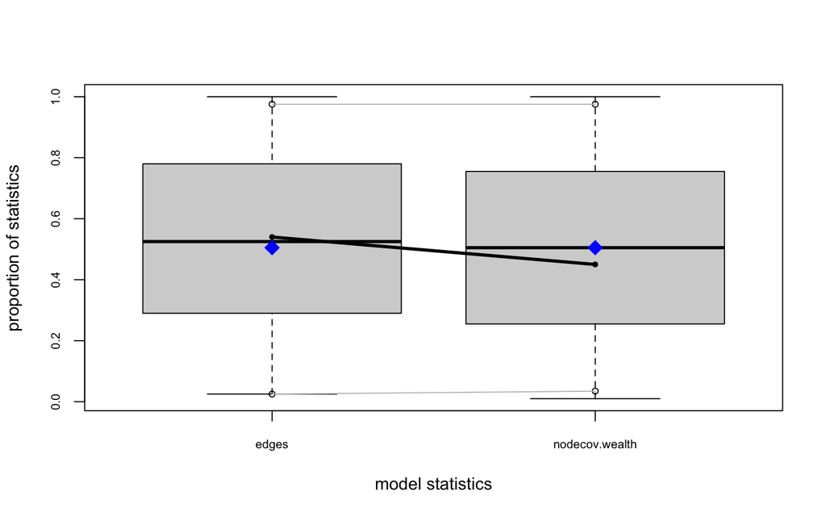

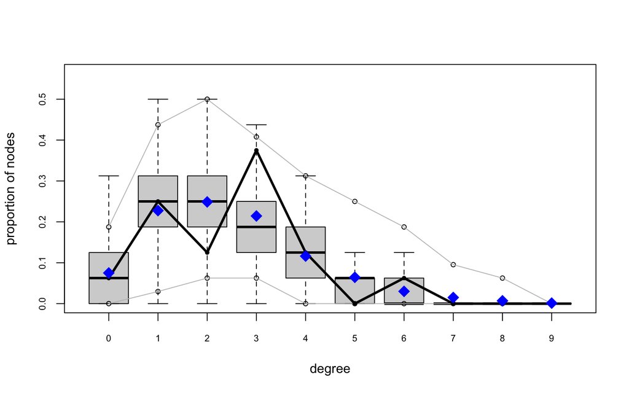

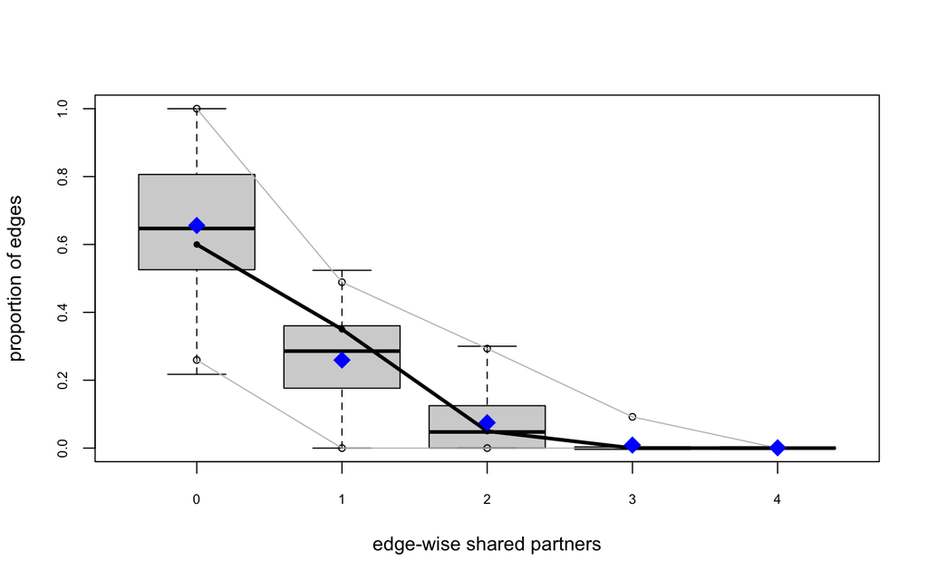

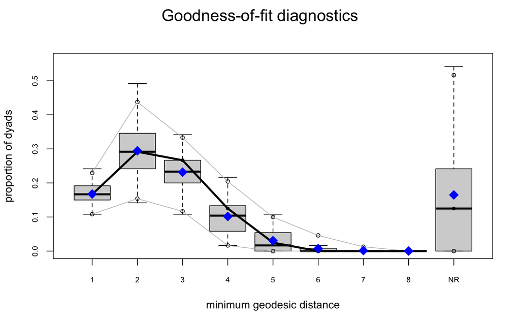

```r
plot(flomodel.03.gof)
```

Let’s see how the `gof` function operates on a larger network by fitting the simplistic edges-only model to the `faux.mesa.high` dataset used earlier:

```r
set.seed(12345)
mesamodel.02 <- ergm(mesa~edges)
```

```
Starting maximum pseudolikelihood estimation (MPLE):
```

```
Evaluating the predictor and response matrix.
```

```
Maximizing the pseudolikelihood.
```

```
Finished MPLE.
```

```
Stopping at the initial estimate.
```

```
Evaluating log-likelihood at the estimate.
```

```r
mesamodel.02.gof <- gof(mesamodel.02~degree + esp + distance,
                        control = snctrl(nsim=10))
```

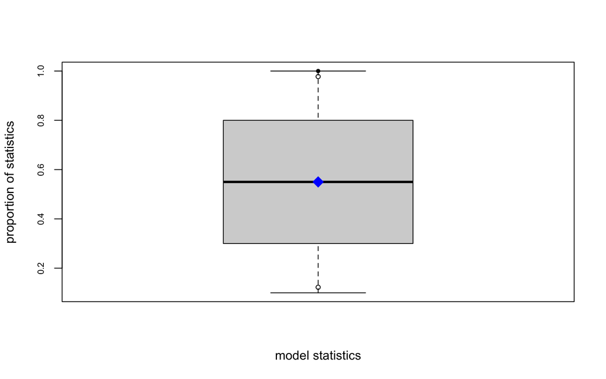

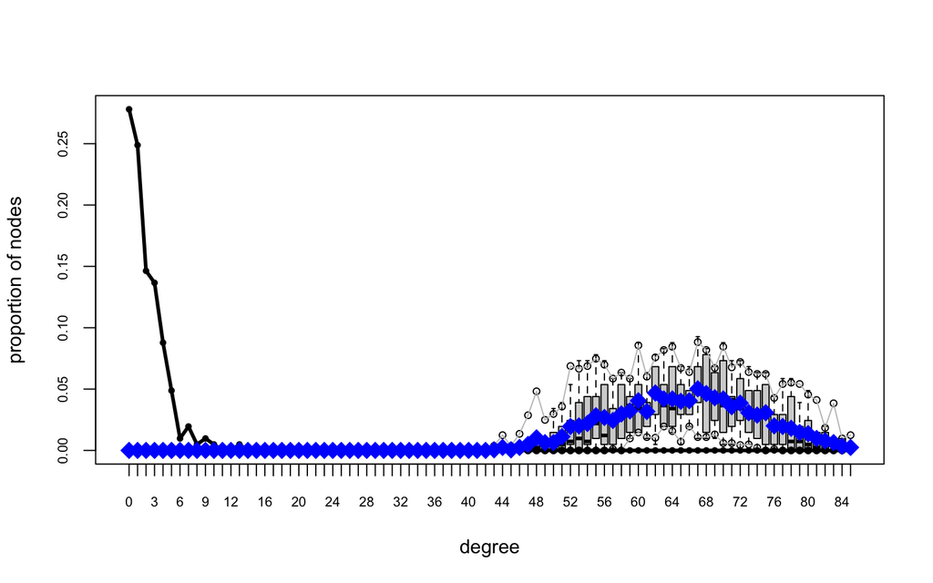

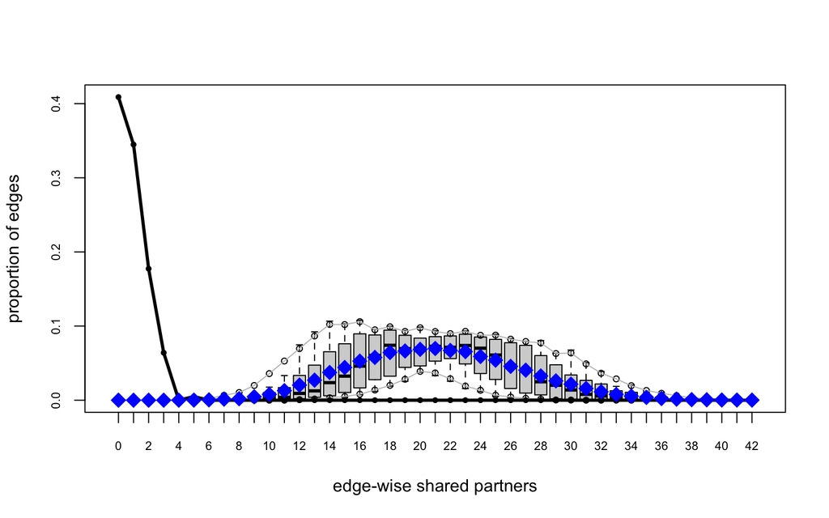

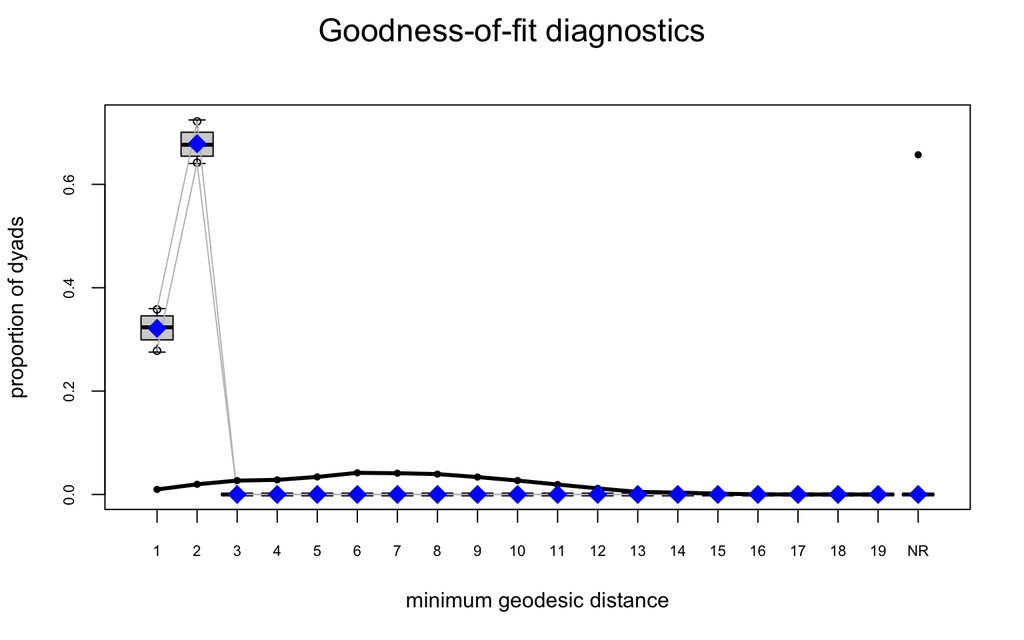

```r
plot(mesamodel.02.gof)
```

Unsurprisingly, networks simulated from the simplistic model do not appear to capture the global structure present in the AddHealth-based `faux.mesa.high` network.

For a good example of model exploration and fitting for the Add Health Friendship networks, see [Goodreau, Kitts & Morris, *Demography* 2009](http://link.springer.com/article/10.1353/dem.0.0045). For more technical details on the approach, see [Hunter, Goodreau and Handcock *JASA* 2008](http://amstat.tandfonline.com/doi/abs/10.1198/016214507000000446?journalCode=uasa20#.U7HZgPldWSo)

## 7. Diagnostics: troubleshooting and checking for model degeneracy

When a model is not a good representation of the observed network, the simulated networks produced in the MCMC chains may be far enough away from the observed network that the estimation process is affected. In the worst case scenario, the simulated networks will be so different that the algorithm fails altogether. When this happens, it basically means the model specified would not have produced the network observed. Some classes of models, we now know, can almost never produce an interesting network, such as we might observe. This behavior is what we call “model degneracy.”

For more detailed discussion of model degeneracy in the ERGM context, see the papers listed in the reference section.

In that worst case scenario, we end up not being able to obtain coefficent estimates, so we can’t use the GOF function to identify how the model simulations deviate from the observed data. We can, however, still use the MCMC diagnostics to observe what is happening with the simulation algorithm, and this (plus some experience and intuition about the behavior of ergm-terms) can help us improve the model specification.

### What it looks like when a model fails

For this purpose, we’ll use a larger network, `faux.magnolia.high`, and look at a simple model for triad closure that includes only `edges` and `triangle` terms.

```r
set.seed(10)
data('faux.magnolia.high')
magnolia <- faux.magnolia.high
magnolia
```

```
 Network attributes:
  vertices = 1461
  directed = FALSE
  hyper = FALSE
  loops = FALSE
  multiple = FALSE
  bipartite = FALSE
  total edges= 974
    missing edges= 0
    non-missing edges= 974

 Vertex attribute names:
    Grade Race Sex vertex.names

 Edge attribute names not shown
```

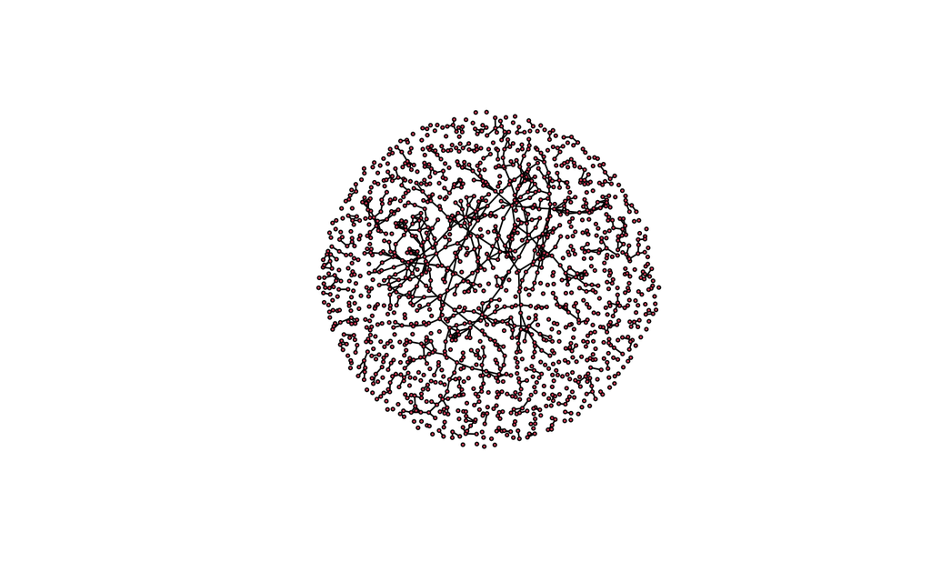

```r
plot(magnolia, vertex.cex=.5)
```

```r
summary(magnolia~edges+triangle) # Simple model for triad closure
```

```
   edges triangle
     974      169
```

We now try to fit this “simple” model:

```r
set.seed(100)
fit <- ergm(magnolia~edges+triangle,
            control=snctrl(MCMLE.effectiveSize=NULL))
```

```
Starting maximum pseudolikelihood estimation (MPLE):
Evaluating the predictor and response matrix.
Maximizing the pseudolikelihood.
Finished MPLE.
Starting Monte Carlo maximum likelihood estimation (MCMLE):
...
Iteration 4 of at most 60:
Optimizing with step length 0.3963.
The log-likelihood improved by 1.1568.
Estimating equations are not within tolerance region.
Iteration 5 of at most 60:
Error in ergm.MCMLE(init, nw, model, initialfit = (initialfit <- NULL),  :
  Number of edges in a simulated network exceeds that in the observed by a factor of more than 20. This is a strong indicator of model degeneracy or a very poor starting parameter configuration. If you are reasonably certain that neither of these is the case, increase the MCMLE.density.guard control…
```

```r
set.seed(1000)
fit <- ergm(magnolia~edges+triangle,
            control=snctrl(MCMLE.maxit=2,MCMLE.effectiveSize=NULL))
```

```
Starting maximum pseudolikelihood estimation (MPLE):
Evaluating the predictor and response matrix.
Maximizing the pseudolikelihood.
Finished MPLE.
Starting Monte Carlo maximum likelihood estimation (MCMLE):
Iteration 1 of at most 2:
Optimizing with step length 0.2805.
The log-likelihood improved by 3.0798.
Estimating equations are not within tolerance region.
Iteration 2 of at most 2:
Optimizing with step length 0.0420.
The log-likelihood improved by 4.6627.
Estimating equations are not within tolerance region.
MCMLE estimation did not converge after 2 iterations. The estimated coefficients may not be accurate. Estimation may be resumed by passing the coefficients as initial values; see 'init' under ?control.ergm for details.
Finished MCMLE.
Evaluating log-likelihood at the estimate. Fitting the dyad-independent submodel...
Bridging between the dyad-independent submodel and the full model...
Setting up bridge sampling...
Using 16 bridges: 1 2 3 4 5 6 7 8 9 10 11 12 13 14 15 16 .
Bridging finished.
This model was fit using MCMC.  To examine model diagnostics and check for degeneracy, use the mcmc.diagnostics() function.
```

Let’s use the MCMC diagnostics from Section 4 to get a sense of what happened:

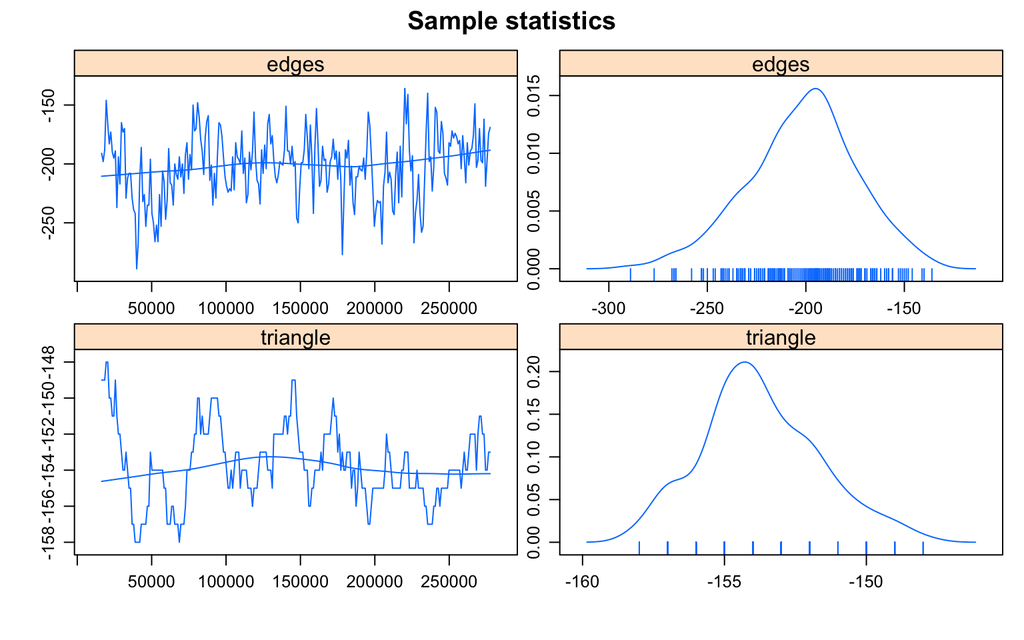

```r
mcmc.diagnostics(fit)
```

The `edges + triangle` model class turns out to be one of the classic degenerate model specifications, and we now understand much more about why it does not produce reasonable levels of triadic closure.

We also now have a more robust way of modeling triangles: the geometrically-weighed edgewise shared partner term (GWESP). For a technical introduction to GWESP, see [Hunter and Handcock, 2006](http://www.tandfonline.com/doi/abs/10.1198/106186006X133069#.U6R5WfldWSo); for a more intuitive description and empirical application, see [Goodreau, Kitts & Morris, 2009](http://link.springer.com/article/10.1353/dem.0.0045) )

Let’s see what using `gwesp` instead of `triangle` can do. We can also control the number of Metropolis-Hastings (MCMC) proposals between sampled statistics in our Markov chain, one of the many control parameters that may be passed to functions in the `ergm` package using the `control=snctrl()` syntax. (To see the many control parameters that may be set by the user in the `ergm` package, type `?snctrl`.)

```r
set.seed(10101)
fit <- ergm(magnolia~edges+gwesp(0.25, fixed=T),
            control=snctrl(MCMC.interval = 10000),
            verbose=T)
```

```
Evaluating network in model.
Initializing unconstrained Metropolis-Hastings proposal: ‘ergm:MH_TNT’.
Model initialized.
Using initial method 'MPLE'.
Fitting initial model.
Starting maximum pseudolikelihood estimation (MPLE):
Evaluating the predictor and response matrix.
Maximizing the pseudolikelihood.
Finished MPLE.
Starting Monte Carlo maximum likelihood estimation (MCMLE):

 ... (output snipped)

Bridging finished.
This model was fit using MCMC.  To examine model diagnostics and check for degeneracy, use the mcmc.diagnostics() function.
```

```r
mcmc.diagnostics(fit)
```

```
Sample statistics summary:

Iterations = 2800000:55400000
Thinning interval = 40000
Number of chains = 1
Sample size per chain = 1316

1. Empirical mean and standard deviation for each variable,
   plus standard error of the mean:

                  Mean    SD Naive SE Time-series SE
edges            7.866 39.98   1.1020          4.141
gwesp.fixed.0.25 7.206 31.99   0.8819          3.360

2. Quantiles for each variable:

                   2.5%    25%   50%   75% 97.5%
edges            -66.12 -18.25 6.000 34.00 93.12
gwesp.fixed.0.25 -57.14 -13.50 8.166 27.07 71.32


Are sample statistics significantly different from observed?
                edges gwesp.fixed.0.25 Overall (Chi^2)
diff.      7.86626140       7.20579674              NA
test stat. 1.89941461       2.14437967      6.19661638
P-val.     0.05750998       0.03200248      0.04675916

Sample statistics cross-correlations:
                     edges gwesp.fixed.0.25
edges            1.0000000        0.7833691
gwesp.fixed.0.25 0.7833691        1.0000000

Sample statistics auto-correlation:
Chain 1
               edges gwesp.fixed.0.25
Lag 0      1.0000000        1.0000000
Lag 40000  0.5460541        0.8587880
Lag 80000  0.4618254        0.7501801
Lag 120000 0.4129546        0.6642087
Lag 160000 0.3832516        0.5940199
Lag 2e+05  0.3082655        0.5300815

Sample statistics burn-in diagnostic (Geweke):
Chain 1

Fraction in 1st window = 0.1
Fraction in 2nd window = 0.5

           edges gwesp.fixed.0.25
          0.1445          -0.1057

Individual P-values (lower = worse):
           edges gwesp.fixed.0.25
       0.8850903        0.9158320
Joint P-value (lower = worse):  0.3733633 .
```

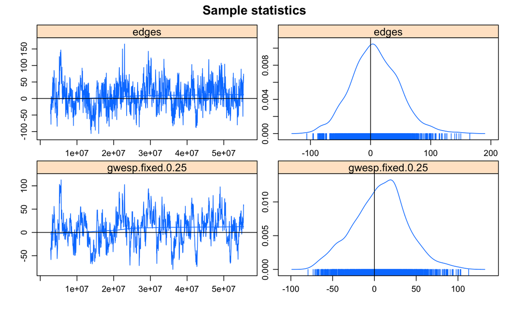

```
MCMC diagnostics shown here are from the last round of simulation, prior to computation of final parameter estimates. Because the final estimates are refinements of those used for this simulation run, these diagnostics may understate model performance. To directly assess the performance of the final…
```

**MORAL:** Degeneracy is an indicator of a poorly specified model. It is not a property of all ERGMs, but it is associated with some dyadic-dependent terms, in particular, the reduced homogeneous Markov specifications (e.g., 2-stars and triangle terms). For a good technical discussion of unstable terms, see [Schweinberger 2012.](http://www.tandfonline.com/doi/abs/10.1198/jasa.2011.tm10747#.U6R2FvldWSo) For a discussion of alternative terms that exhibit more stable behavior, see [Snijders et al. 2006.](http://onlinelibrary.wiley.com/doi/10.1111/j.1467-9531.2006.00176.x/abstract). For the gwesp term and the curved exponential family terms in general, see [Hunter and Handcock 2006.](http://amstat.tandfonline.com/doi/abs/10.1198/106186006X133069#.U7MxWPldWSo).

## 8. Working with egocentrically sampled network data

One of the most powerful features of ERGMs is that they can be used to estimate models from from egocentrically sampled data, and the fitted models can then be used to simulate complete networks (of any size) that will have the properties of the original network that are observed and represented in the model.

In many empirical contexts, it is not feasible to collect a network census or even an adaptive (link-traced) sample. Even when one of these may be possible in practice, egocentrically sampled data are typically cheaper and easier to collect.

Long regarded as the poor country cousin in the network data family, egocentric data contain a remarkable amount of information. With the right statistical methods, such data can be used to explore the properties of the complete networks in which they are embedded. The basic idea here is to combine what is observed with assumptions to define a class of models that describes the distribution of networks that are centered on the observed properties. The variation in these networks quantifies some of the uncertainty introduced by the assumptions.

The egocentric estimation/simulation framework extends to temporal ERGMs (“TERGMs”) as well, with the minimal addition of an estimate of partnership duration. This makes it possible to simulate complete dynamic networks from a single cross-sectional egocentrically sampled network. For an example of what one can accomplish with this framework, check out the network movie we developed to explore the impact of dynamic network structure on HIV transmission at http://statnet.org/movies.

While the `ergm` package has had this capability for many years, and old versions of this workshop had a detailed section on it, there is now a specific package that makes this much easier: `ergm.ego`. The new package includes accurate statistical inference, i.e., standard errors for model coefficient estimates, along with many utilities that simplify the task of reading in the data, conducting exploratory analyses, calculating the sample target statistics, and specifying model options.

We now have a separate workshop/tutorial for `ergm.ego`, so we no longer cover this material in the current ERGM workshop. As always, this workshop material can be found online at the [Statnet Workshops wiki](https://github.com/statnet/Workshops/wiki).

## 9. Additional functionality in statnet and other packages

“Statnet” refers to a suite of `R` packages that are designed to work together, providing tools for a wide range of different types of network data analysis.  
There is also an R package called `statnet`, whose sole function is to make it easy to install and load all of the packages produced by the Statnet Project team in a single step.

Examples of Statnet Suite functionality beyond the `ergm` package include temporal network models and dynamic network vizualizations, analysis of egocentrically sampled network data, multilevel network modeling, latent cluster models, and network diffusion and epidemic models. Development is ongoing, with new packages and new functionality added to existing packages on a regular basis.

Most of the Statnet packages can be downloaded from CRAN, and all are available via GitHub. For more detailed information, please visit the `statnet` webpage at [www.statnet.org](http://statnet.org).

### Current statnet packages

Packages developed by the Statnet team that are not covered in this tutorial:

- `sna` — classical social network analysis utilities
- `tsna` — descriptive statistics for temporal network data
- `tergm` — temporal ergms for dynamic networks
- `ergm.ego`— estimation/simulation of ergms from egocentrically sampled data
- `ergm.count` — models for tie count network data
- `ergm.rank` — models for tie rank network data
- `relevent` — relational event models for networks
- `latentnet` — latent space and latent cluster analysis
- `degreenet` — MLE estimation for degree distributions (negative binomial, Poisson, scale-free, etc.)
- `networksis` — simulation of bipartite networks with given degree distributions
- `ndtv` package — network movie maker
- `EpiModel` — network modeling of infectious disease and social diffusion processes
- `ergm.multi` — ERGMs for multiple or multilayer networks
- `ergm.userterms` — template for users who want to implement their own new ERGM terms. (available on GitHub only)

Many of these packages have associated training workshops. Our tutorials can be found online, on the [GitHub statnet Workshops wiki](https://statnet.github.io/Workshops).

### Additional functionality in base `ergm`

- ERGMs for valued ties

### Extensions by other developers

There are now a number of excellent packages developed by others that extend the functionality of statnet. The easiest way to find these is to look at the “reverse depends” of the `ergm` package on [CRAN](https://cran.org/packages). Examples include:

- `Bergm` — Bayesian Exponential Random Graph Models
- `btergm` — Temporal Exponential Random Graph Models by Bootstrapped Pseudolikelihood
- `hergm` — hierarchical ERGMs for multi-level network data
- `xergm` — extensions to ERGM modeling

### Statnet Commons: The development group

Mark S. Handcock `<handcock@stat.ucla.edu>`

David R. Hunter `<dhunter@stat.psu.edu>`

Carter T. Butts `<buttsc@uci.edu>`

Steven M. Goodreau `<goodreau@u.washington.edu>`

Skye Bender-deMoll `<skyebend@skyeome.net>`

Martina Morris `<morrism@u.washington.edu>`

Pavel N. Krivitsky `<p.krivitsky@unsw.edu.au>`

Samuel M. Jenness `<samuel.m.jenness@emory.edu>`

Chad Klumb `<cklumb@gmail.com>`

Michal Bojanowski `<mbojanowski@kozminski.edu.pl>`

## Appendix A: Clarifying the terms “ergm” and “network”

You will see the terms ergm and network used in multiple contexts throughout the documentation. This is common in R, but often confusing to newcomers. To clarify:

**ergm**

- **ERGM**: the acronym for an Exponential Random Graph Model; a statistical model for relational data that takes a generalized exponential family form.
- **ergm package**: one of the packages within the `statnet` suite
- **ergm function**: a function within the ergm package; fits an ERGM to a network object, creating an ergm object in the process.
- **ergm object**: a class of objects produced by a call to the ergm function, representing the results of an ERGM fit to a network.

**network**

- **network**: a set of actors and the relations among them. Used interchangeably with the term graph.
- **network package**: one of the packages within the `statnet` suite; used to create, store, modify and plot the information found in network objects.
- **network object**: a class of object in `R` used to represent a network.

## References

For a general orientation to the `statnet` packages, the best place to start is the special volume of the *Journal of Statistical Software* (JSS) devoted to `statnet`: https://www.jstatsoft.org/issue/view/v024. The nine papers in this volume cover a wide range of theoretical and practical topics related to ERGMs, and their implementation in `statnet`.

However, this volume was written in 2008. The `statnet` code base has evolved considerably since that time, and with the release of `ergm` version 4.0, the most current paper describing the capabilities of the `ergm` package is the following preprint:

Krivitsky, P. N., David R. Hunter, Martina Morris, and Chad Klumb (2021). ergm 4.0: New Features and Improvements. https://arxiv.org/abs/2106.04997.

For social scientists, a good introductory application paper is:

Goodreau, S., J. Kitts and M. Morris (2009). Birds of a Feather, or Friend of a Friend? Using Statistical Network Analysis to Investigate Adolescent Social Networks. *Demography* 46(1): 103-125. [link](http://link.springer.com/article/10.1353/dem.0.0045)

**Dealing with Model Degeneracy**

Handcock MS (2003a). “Assessing Degeneracy in Statistical Models of Social Networks.” Working Paper 39, Center for Statistics and the Social Sciences, University of Washington. [link](http://www.csss.washington.edu/research/working-papers/39)

Schweinberger, Michael (2011) Instability, Sensitivity, and Degeneracy of Discrete Exponential Families *JASA* 106(496): 1361-1370. [link](http://www.tandfonline.com/doi/abs/10.1198/jasa.2011.tm10747#.U7M4A_ldWSo)

Snijders, TAB et al (2006) New Specifications For Exponential Random Graph Models  
*Sociological Methodology* 36(1): 99-153 [link](http://onlinelibrary.wiley.com/doi/10.1111/j.1467-9531.2006.00176.x/abstract)

Hunter, D. R. (2007). Curved Exponential Family Models for Social Networks. *Social Networks*, 29(2), 216-230.[link](https://www.ncbi.nlm.nih.gov/pmc/articles/PMC2031865/)

**Temporal ERGMs**

Krivitsky, P.N., Handcock, M.S,(2014). A separable model for dynamic networks *JRSS Series B-Statistical Methodology*, 76(1):29-46; 10.1111/rssb.12014 JAN 2014 [link](https://www.ncbi.nlm.nih.gov/pmc/articles/PMC3891677/)

Krivitsky, P. N., M. S. Handcock and M. Morris (2011). Adjusting for Network Size and Composition Effects in Exponential-family Random Graph Models, *Statistical Methodology* 8(4): 319-339, ISSN 1572-3127 [link](https://www.ncbi.nlm.nih.gov/pmc/articles/PMC3117581/)

**Egocentric ERGMS**

Krivitsky, P. N., & Morris, M. (2017). Inference for social network models from egocentrically sampled data, with application to understanding persistent racial disparities in HIV prevalence in the US. *Annals of Applied Statistics*, 11(1), 427-455.[link](https://www.ncbi.nlm.nih.gov/pmc/articles/PMC5737754/)